```python
%%shell
jupyter nbconvert --to html "/content/Project_7.ipynb"
```

```
[NbConvertApp] Converting notebook /content/Project_7.ipynb to html
[NbConvertApp] WARNING | Alternative text is missing on 5 image(s).
[NbConvertApp] Writing 555870 bytes to /content/Project_7.html
```

# Project 7: Data Exploration and Visualization

### Overview

In this project, you will apply data exploration and visualization techniques to a real-world dataset of your choice. You'll practice using pandas for data analysis and create meaningful visualizations to gain insights from your data. This project builds on your Python programming skills while introducing you to the exciting world of data science.

In [Lab7](https://colab.research.google.com/drive/15QvSh0csZaCU-OuuPIfpWx5wLDDjmqK4?usp=sharing), you explore the titanic dataset and you should use it as a sample and pick a dataset of your interest to do a similar data exploration and visualization.

### Project Objectives

- Find and select a dataset from a real-world data source
- Formulate a clear inquiry question based on your chosen dataset
- Perform exploratory data analysis using pandas functions
- Create at least two meaningful data visualizations
- Analyze your findings and answer your inquiry question
- Reflect on the insights gained through data exploration

### Data Sources

You can choose from various online data sources such as:

- [Kaggle](https://www.kaggle.com/datasets) - Wide variety of datasets
- [data.gov](https://www.data.gov/) - U.S. government data
- [Our World in Data](https://ourworldindata.org/) - Global development data
- [GitHub](https://github.com/datasets) - Curated datasets
- [Google Dataset Search](https://datasetsearch.research.google.com/) - Search for datasets
- Or any other reliable data source you find interesting

## Part 1: Dataset Selection and Initial Exploration

#### TODO Tasks:

1. Select Your Dataset: Choose a dataset that interests you. Make sure it has at least 100 rows and multiple columns with different data types (e.g., numerical, categorical, dates).

Please create either text or code cells in between the TODO tasks to do the work.

2. Import Libraries: Import the necessary libraries (pandas, matplotlib, seaborn) at the beginning of your notebook by creating code cells below this text cell.
3. Load Your Data: Load your chosen dataset using pandas and save it to a pandas dataframe. Please create a code cell below this text cell to do it.

```python
# prompt: I uploaded the chocolate_sales_data.csv can you import it and save the data in the pandas data frame?

import pandas as pd

# Assuming the file is uploaded to the default content directory
df = pd.read_csv('/content/chocolate_sales_data.csv')

print(df.head(100))
```

```
       Sales Person      Country              Product       Date    Amount  \
0    Jehu Rudeforth           UK      Mint Chip Choco  04-Jan-22   $5,320
1       Van Tuxwell        India        85% Dark Bars  01-Aug-22   $7,896
2      Gigi Bohling        India  Peanut Butter Cubes  07-Jul-22   $4,501
3      Jan Morforth    Australia  Peanut Butter Cubes  27-Apr-22  $12,726
4    Jehu Rudeforth           UK  Peanut Butter Cubes  24-Feb-22  $13,685
..              ...          ...                  ...        ...       ...
95  Roddy Speechley  New Zealand         Orange Choco  01-Apr-22      $49
96   Beverie Moffet    Australia              Eclairs  20-Jun-22   $1,827
97    Kelci Walkden           UK     Fruit & Nut Bars  29-Jun-22  $13,006
98   Marney O'Breen          USA       50% Dark Bites  15-Jun-22   $1,064
99     Husein Augar          USA          After Nines  08-Apr-22  $11,571

    Boxes Shipped
0             180
1              94
2              91
3             342
4             184
..            ...
95             97
96              6
97            482
98            106
99            180

[100 rows x 6 columns]
```

4. Data Summary: Use the following functions to do inital exploration your dataset:
- info() - Display information about the dataset structure
- describe() - Show statistical summary of numerical columns
- head() - Display the first 5 rows (df.head())
- shape - Show the dimensions of the dataset (e.g. df.shape)
- columns - Get the column names (e.g. df.columns)

You may use 5 code cells below this text cell to accomplish it.

```python
df.info()
```

```
<class 'pandas.core.frame.DataFrame'>
RangeIndex: 1094 entries, 0 to 1093
Data columns (total 6 columns):
 #   Column         Non-Null Count  Dtype
---  ------         --------------  -----
 0   Sales Person   1094 non-null   object
 1   Country        1094 non-null   object
 2   Product        1094 non-null   object
 3   Date           1094 non-null   object
 4   Amount         1094 non-null   object
 5   Boxes Shipped  1094 non-null   int64
dtypes: int64(1), object(5)
memory usage: 51.4+ KB
```

```python
df.describe()
```

|  | Boxes Shipped |
| --- | --- |
| count | 1094.000000 |
| mean | 161.797989 |
| std | 121.544145 |
| min | 1.000000 |
| 25% | 70.000000 |
| 50% | 135.000000 |
| 75% | 228.750000 |
| max | 709.000000 |

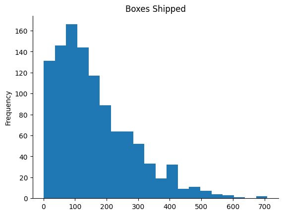

```python
from matplotlib import pyplot as plt
df['Boxes Shipped'].plot(kind='hist', bins=20, title='Boxes Shipped')
plt.gca().spines[['top', 'right',]].set_visible(False)
```

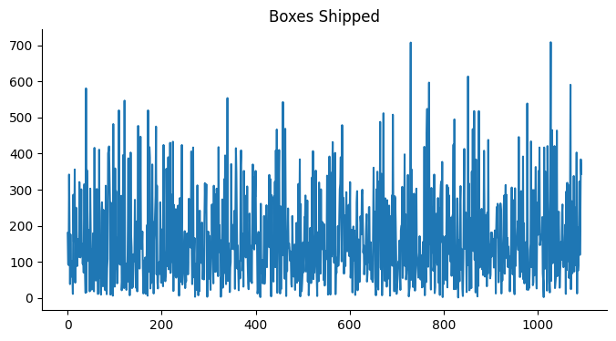

```python
from matplotlib import pyplot as plt
df['Boxes Shipped'].plot(kind='line', figsize=(8, 4), title='Boxes Shipped')
plt.gca().spines[['top', 'right']].set_visible(False)
```

```python
df.head()
```

|  | Sales Person | Country | Product | Date | Amount | Boxes Shipped |
| --- | --- | --- | --- | --- | --- | --- |
| 0 | Jehu Rudeforth | UK | Mint Chip Choco | 04-Jan-22 | $5,320 | 180 |
| 1 | Van Tuxwell | India | 85% Dark Bars | 01-Aug-22 | $7,896 | 94 |
| 2 | Gigi Bohling | India | Peanut Butter Cubes | 07-Jul-22 | $4,501 | 91 |
| 3 | Jan Morforth | Australia | Peanut Butter Cubes | 27-Apr-22 | $12,726 | 342 |
| 4 | Jehu Rudeforth | UK | Peanut Butter Cubes | 24-Feb-22 | $13,685 | 184 |

```python
df.shape
```

```
(1094, 6)
```

```python
df.columns
```

```
Index(['Sales Person', 'Country', 'Product', 'Date', 'Amount',
       'Boxes Shipped'],
      dtype='object')
```

5. Inquiry Question: Write a clear, specific question that you want to answer using your dataset by creating a text cell below and **write the question in bold please.**

For example:

- "How has the average temperature changed in major cities over the past decade?"
- "What factors are most strongly correlated with housing prices?"
- "Is there a relationship between education level and income?"

## Part 2: Data Visualization and Analysis

#### TODO Tasks:

1. Data Cleaning (if necessary): Check for and handle any missing values, duplicates, or data quality issues.

**NOTE: This could be a daunting task even for seasoned data scientists. My suggestion is to use a dataset that is already clean if you can for the purpose of completing this assignment in a week.**

Examples:

- Checking for missing values: df.isnull().sum()
- Dropping rows with any missing values: df.dropna(inplace=True)
- Dropping columns with all missing values: df.dropna(axis=1, how='all', inplace=True)
- Removing duplicate row: df.drop_duplicates(inplace=True)
2. Create Visualizations: Create at least 2 different types of visualizations that help answer your research question. Choose from:
- Bar charts
- Line plots
- Scatter plots
- Histograms
- Box plots
- Heatmaps
- Any other appropriate visualization
3. Customize Your Plots: Make sure your visualizations are clear and informative by:
- Adding appropriate titles
- Labeling axes
- Using colors effectively
- Adding legends when necessary

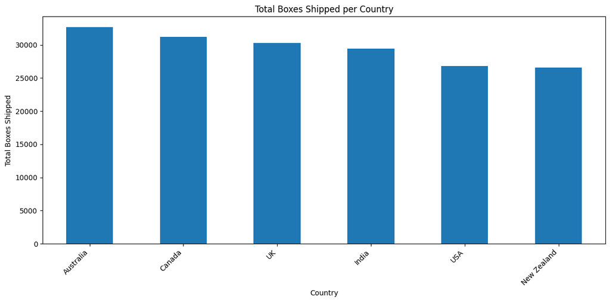

```python
# prompt: how do I get a chart of how many boxes were shipped out of which country

import matplotlib.pyplot as plt
# Group by country and sum the 'Boxes Shipped'
boxes_by_country = df.groupby('Country')['Boxes Shipped'].sum().sort_values(ascending=False)

# Create a bar chart
plt.figure(figsize=(12, 6))
boxes_by_country.plot(kind='bar')
plt.title('Total Boxes Shipped per Country')
plt.xlabel('Country')
plt.ylabel('Total Boxes Shipped')
plt.xticks(rotation=45, ha='right')
plt.tight_layout()
plt.show()
```

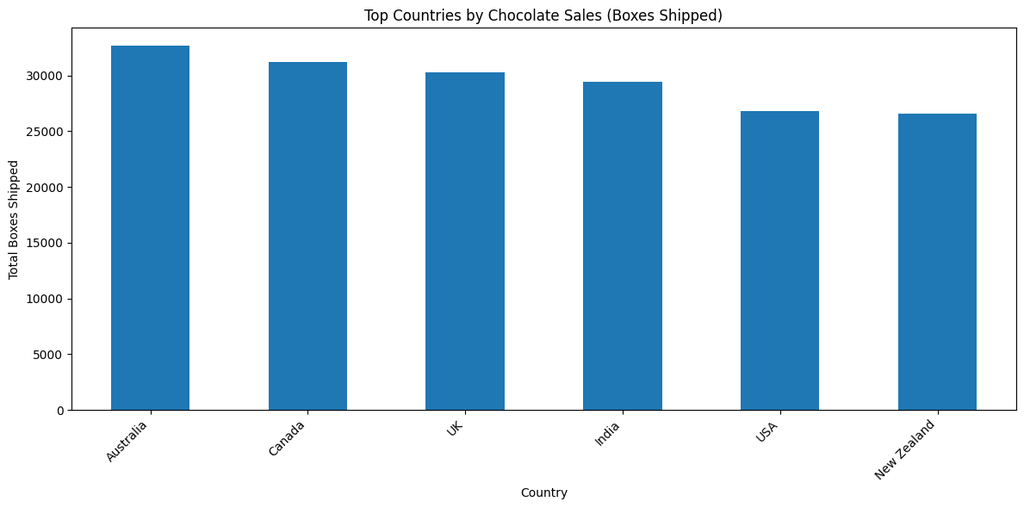

```python
# prompt: which countries sold the most chocolate in a graph?

import matplotlib.pyplot as plt
# Assuming 'Country' column exists and 'Boxes Shipped' represents sales volume
# Group by country and sum the 'Boxes Shipped' to get total sales per country
country_sales = df.groupby('Country')['Boxes Shipped'].sum().sort_values(ascending=False)

# Select the top N countries (e.g., top 10)
top_countries = country_sales.head(10)

# Create a bar plot
plt.figure(figsize=(12, 6))
top_countries.plot(kind='bar')
plt.title('Top Countries by Chocolate Sales (Boxes Shipped)')
plt.xlabel('Country')
plt.ylabel('Total Boxes Shipped')
plt.xticks(rotation=45, ha='right')
plt.tight_layout() # Adjust layout to prevent labels overlapping
plt.show()
```

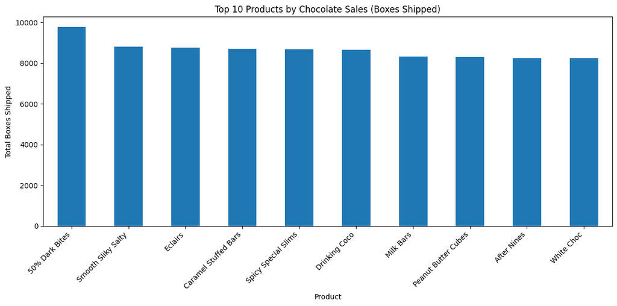

```python
# prompt: which products sold the most amount in a chart

import matplotlib.pyplot as plt
# To find which products sold the most amount, we need to group by 'Product' and sum the 'Boxes Shipped'.
product_sales = df.groupby('Product')['Boxes Shipped'].sum().sort_values(ascending=False)

# Select the top N products (e.g., top 10) to display on the chart
top_products = product_sales.head(10)

# Create a bar plot for the top products by sales
plt.figure(figsize=(12, 6))
top_products.plot(kind='bar')
plt.title('Top 10 Products by Chocolate Sales (Boxes Shipped)')
plt.xlabel('Product')
plt.ylabel('Total Boxes Shipped')
plt.xticks(rotation=45, ha='right') # Rotate labels for better readability if product names are long
plt.tight_layout() # Adjust layout to prevent labels overlapping
plt.show()
```

```python
# prompt: which country sold the highest amount of product

# To find the country that sold the highest amount of product, we can use the `idxmax()` method on the `country_sales` Series.
highest_selling_country = country_sales.idxmax()
highest_sales_amount = country_sales.max()

print(f"The country that sold the highest amount of product is: {highest_selling_country} with a total of {highest_sales_amount} boxes shipped.")
```

```
The country that sold the highest amount of product is: Australia with a total of 32647 boxes shipped.
```

Please create code cells below this to create your visualizations.

4. Analysis: Write 1-2 paragraphs discussing:
- Whether your research question can be answered with the available data
- What insights you discovered through your visualizations
- Any unexpected or interesting findings
- Limitations of your analysis
- Suggestions for further investigation

Please create a text cell below this cell to write your analysis.

I saw that when I asked Gemini how to list the data, I needed the title of the chart to be changed to specify the x and y axis titles to boxes shipped not just total boxes shipped per country because I wanted to list from highest to lowest who was selling the most.

I see that the program is literal, when you upload the data it will only respond to the keyword that is used in the column, or else it won't recognize "sales" or the "sales person" even if I know that. I've found out that the country that sold the most chocolate was Australia and I was able to get the specific amount of boxes which was 32,647. Also based on flavor the top amount of sales was made on 50% dark chocolate bites, which I was surprised at both the coutry and what flavor they chose.

## NOTE: If you use a local dataset, you MUST submit the dataset along with your notebook to get credit.

- Download your notebook as CS110_Project7.ipynb
- Ensure all TODO tasks are completed
- Make sure your code runs without errors
- Include clear comments explaining your work
- Submit the notebook file

## Grading Criteria (4 points)

- Dataset Selection: Appropriate choice of dataset with sufficient complexity
- Inquiry Question: Clear, specific, and answerable with the chosen data
- Data Exploration: Proper use of pandas functions for initial analysis
- Visualizations: At least 2 clear, well-formatted, and relevant plots
- Analysis: Thoughtful interpretation of findings and answer to research question
- Code Quality: Clean, commented, and well-organized code

Remember: The goal is not just to create visualizations, but to use them to gain meaningful insights about your data. Think like a data scientist and let your curiosity guide your exploration!

```python
from google.colab import files

uploaded = files.upload()

for fn in uploaded.keys():
  print('User uploaded file "{name}" with length {length} bytes'.format(
      name=fn, length=len(uploaded[fn])))
```

Upload widget is only available when the cell has been executed in the current browser session. Please rerun this cell to enable.

```
Saving chocolate_sales_data.csv to chocolate_sales_data (2).csv
User uploaded file "chocolate_sales_data (2).csv" with length 67501 bytes
```